# HF EOL

Mégane

2023-03-28

Scatter plot Point B vs EOL (T°) :  
Slope : 1.003  
Intercept : 0.040

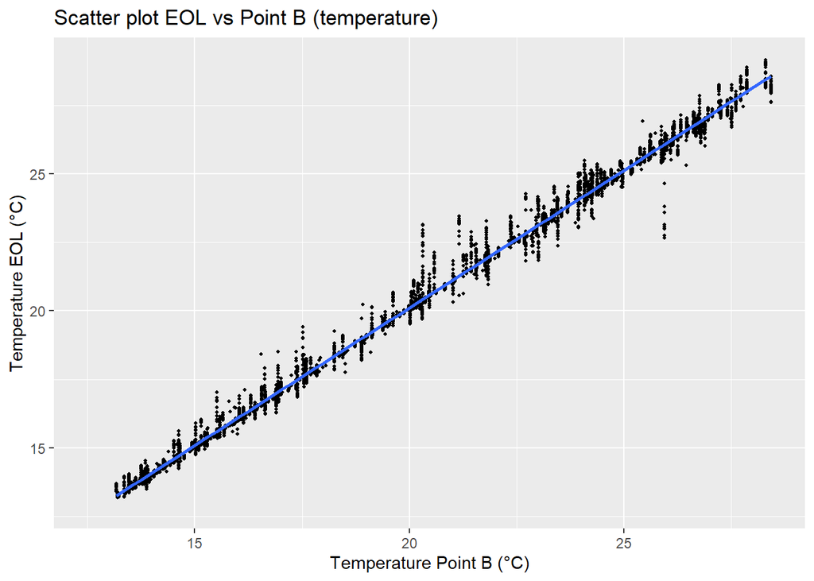

## Data EOL surface : temperature (°C), salinity and oxygen (µmol.kg<sup>-1</sup>)

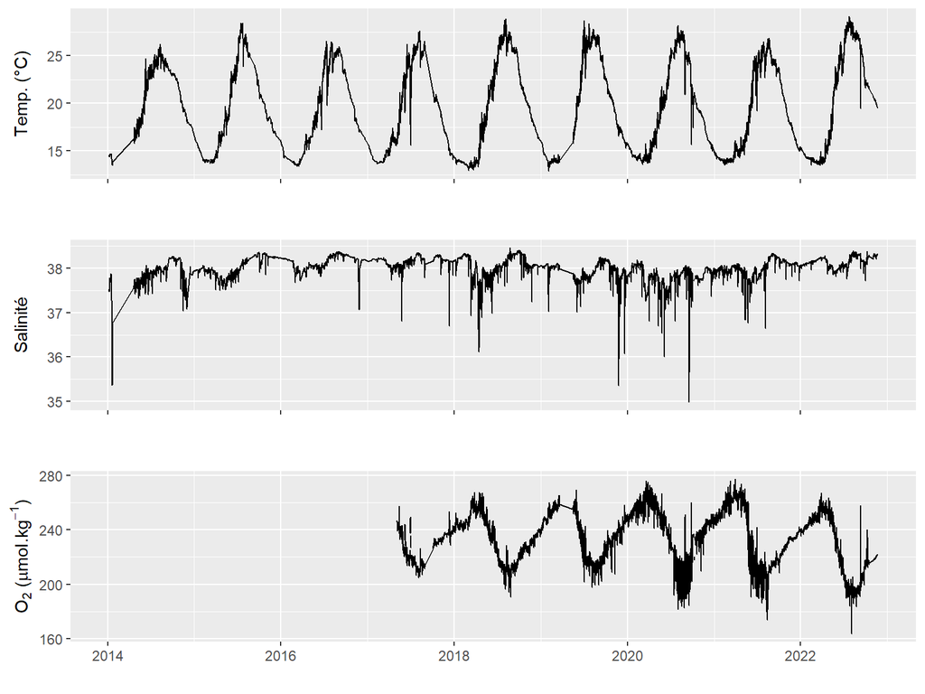

```r
EOL_RAW <- EOL_RAW %>%
  dplyr::filter(datetime >= "2014-01-07 01:00:00" & datetime <= "2022-12-31 01:00:00")

plot_EOL_RAW_temp <- EOL_RAW %>%
  ggplot() +
  aes(x=datetime, y=temperature) +
  geom_line() +
  scale_x_date(name="", labels = NULL) +
  scale_y_continuous(name="Temp. (°C)")

plot_EOL_RAW_sal <- EOL_RAW %>%
  ggplot() +
  aes(x=datetime, y=salinity) +
  geom_line() +
  scale_x_date(name="", labels = NULL) +
  scale_y_continuous(name="Salinité")

plot_EOL_RAW_oxy <- EOL_RAW %>%
  ggplot() +
  aes(x=datetime, y=oxygen) +
  geom_line() +
  scale_x_date(name="") +
  scale_y_continuous(name=expression(paste(O[2], " (", mu, "mol", .kg^-1, ")")))

plot_grid(plot_EOL_RAW_temp, plot_EOL_RAW_sal, plot_EOL_RAW_oxy, align='vh', ncol=1)
```

#### Part 1 : Trend analysis by residuals : raw dataset (jan. 2014 - dec.2022)

*By autocorrelation + decompose function or Mann-Kendall : not possible because of gaps*

###### Table and plot of monthly means (2014-2022) - EOL temperature & salinity

```r
monthly_means <- ungroup(EOL_RAW) %>%
  mutate(Month = format(datetime, format="%m")) %>%
  group_by(Month) %>%
  summarise(
    Salinity_month = mean(salinity, na.rm = TRUE),
    SD_sal = sd(salinity, na.rm = TRUE),
    Temperature_month = mean(temperature, na.rm = TRUE),
    SD_temp = sd(temperature, na.rm = TRUE),
    Oxy_month = mean(oxygen, na.rm = TRUE),
    SD_oxy = sd(oxygen, na.rm= TRUE))


##RAPPORT##

monthly_means_rapport <- monthly_means %>%
  mutate(`T (°C)` = paste(round(Temperature_month, digits=2), "±", round(SD_temp, digits=2)),
         S = paste(round(Salinity_month, digits=2), "±", round(SD_sal, digits=2)),
         `O~2~ (µmol.kg^-1^)` = paste(round(Oxy_month, digits=2), "±", round(SD_oxy, digits=2)))

monthly_means_rapport <- monthly_means_rapport %>%
  dplyr::select(Month, `T (°C)`, S, `O~2~ (µmol.kg^-1^)`, S, Temperature_month) %>%
  rename(`Mois  ` = Month)


kable(monthly_means_rapport, caption="Moyennes mensuelles à EOL (surface)", format = "pipe", align='l')
```

Moyennes mensuelles à EOL (surface)

| Mois | T (°C) | S | O<sub>2</sub> (µmol.kg<sup>-1</sup>) | Temperature_month |
| --- | --- | --- | --- | --- |
| 01 | 14.61 ± 0.58 | 38.04 ± 0.13 | 245.91 ± 4.55 | 14.61366 |
| 02 | 13.93 ± 0.27 | 38.09 ± 0.15 | 251.98 ± 6.61 | 13.93167 |
| 03 | 13.87 ± 0.39 | 37.96 ± 0.26 | 257.89 ± 6.89 | 13.86633 |
| 04 | 15.21 ± 1.1 | 37.87 ± 0.3 | 259.3 ± 5.41 | 15.21470 |
| 05 | 18.18 ± 1.77 | 37.79 ± 0.2 | 248.11 ± 9.29 | 18.17596 |
| 06 | 22.37 ± 1.77 | 37.8 ± 0.23 | 229.45 ± 11.61 | 22.36511 |
| 07 | 25.59 ± 1.7 | 37.96 ± 0.16 | 212.5 ± 9.39 | 25.58686 |
| 08 | 26.28 ± 1.17 | 38.09 ± 0.19 | 207.81 ± 8.13 | 26.28132 |
| 09 | 24.47 ± 1.41 | 38.18 ± 0.17 | 214.21 ± 8.94 | 24.46773 |
| 10 | 21.06 ± 1.07 | 38.15 ± 0.17 | 227.62 ± 5.64 | 21.05961 |
| 11 | 18.59 ± 1.07 | 38.01 ± 0.32 | 232.81 ± 6.68 | 18.59396 |
| 12 | 16.02 ± 0.85 | 38 ± 0.17 | 240.45 ± 5.21 | 16.02496 |

###### Table of time series anomalies regression analyses (2014-2022) - EOL temperature & salinity

```
##                        Slope     SE Slope     P Slope  Intercept    SE int.
## Salinity_ano     0.006824692 0.0004434602 2.59046e-53  -13.78382  0.8956567
## Temperature_ano  0.105458013 0.0025917817 0.00000e+00 -212.99351  5.2346236
## Oxy_ano         -1.126866142 0.0236593444 0.00000e+00 2276.52484 47.7972484
##                       P int.         F    df          R2     P value
## Salinity_ano    2.590813e-53  236.8409 47148 0.004998242 2.59046e-53
## Temperature_ano 0.000000e+00 1655.6264 47182 0.033900632 0.00000e+00
## Oxy_ano         0.000000e+00 2268.5024 42428 0.050753466 0.00000e+00
```

**Plot of anomalies : Temperature (°C) (2014-2022) - EOL**

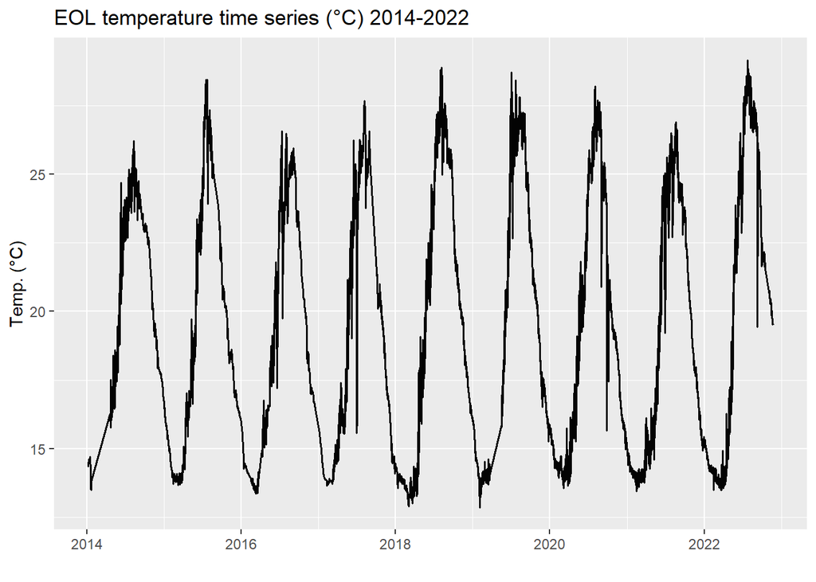

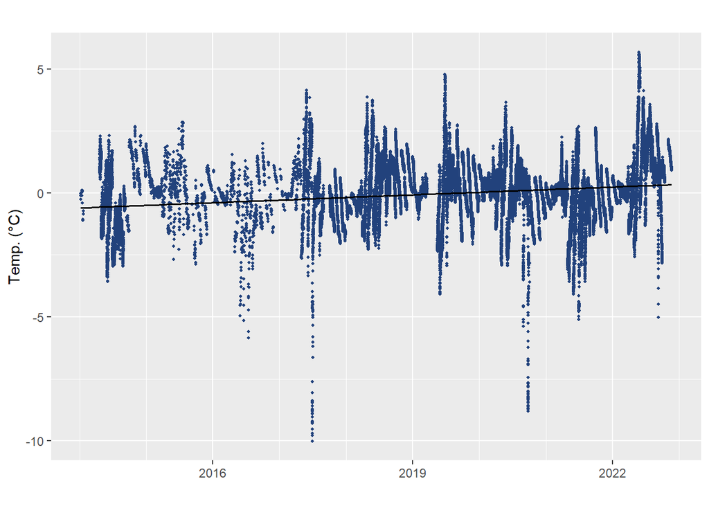

**Plot of anomalies : Salinity (2014-2022) - EOL**

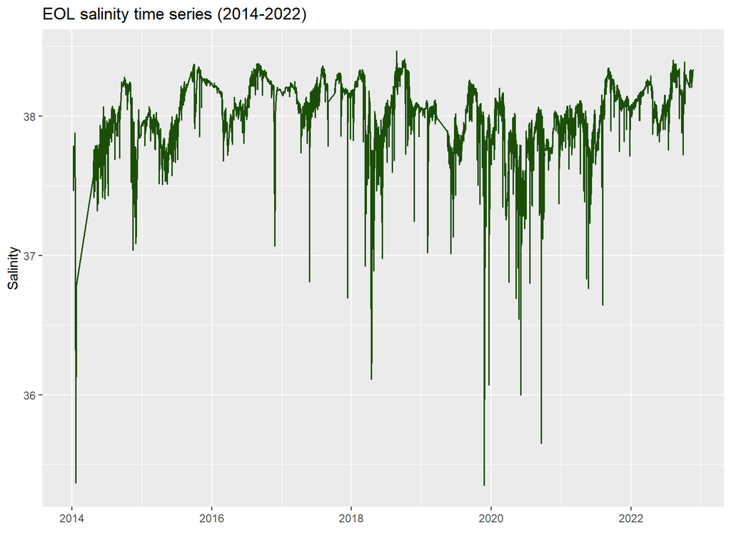

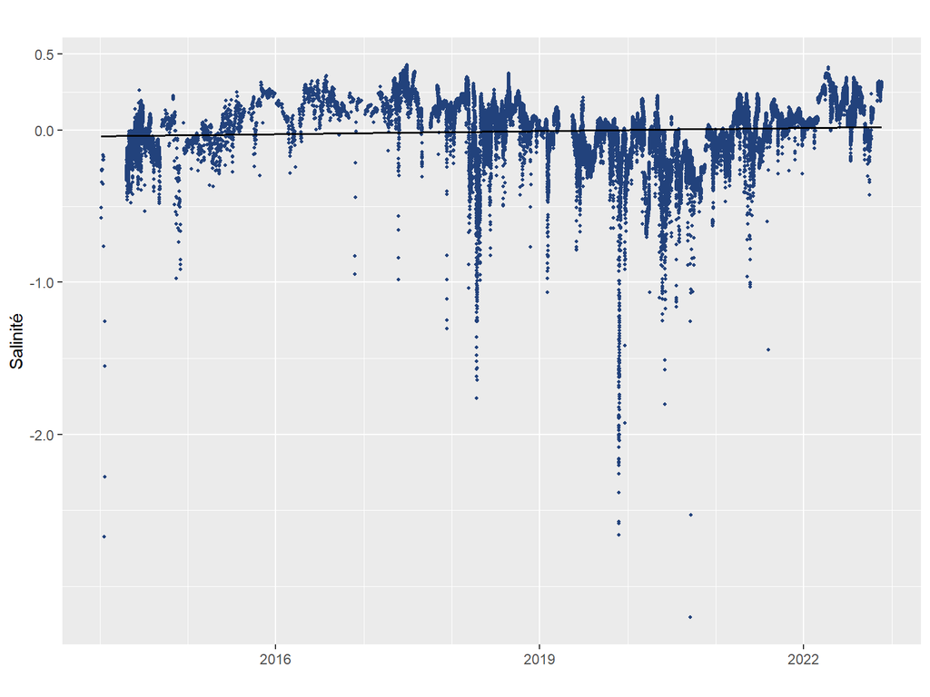

#### Part 2 : Trend analysis by residuals : daily dataset (morning 8AM-10AM) jan.2014 - dec.2022

Missing values :  
- feb + march of 2014 (only one value for december)  
- may, august and september of 2016  
- august and september of 2017  
- april 2019

###### EOL 1 : Table and plot of monthly means (2014-2022) - EOL temperature & salinity

```r
monthly_means_EOL1 <- ungroup(EOL_daily) %>%
  mutate(Month = format(datetime, format="%m")) %>%
  group_by(Month) %>%
  summarise(
    Salinity_month = mean(salinity, na.rm = TRUE),
    Temperature_month = mean(temperature, na.rm = TRUE))

monthly_means_EOL1
```

```
## # A tibble: 12 x 3
##    Month Salinity_month Temperature_month
##    <chr>          <dbl>             <dbl>
##  1 01              38.0              14.6
##  2 02              38.1              13.9
##  3 03              38.0              13.8
##  4 04              37.9              15.2
##  5 05              37.8              17.9
##  6 06              37.8              22.1
##  7 07              38.0              25.5
##  8 08              38.1              26.1
##  9 09              38.2              24.2
## 10 10              38.2              21.1
## 11 11              38.0              18.1
## 12 12              38.0              16.3
```

###### EOL 1 : Table of time series anomalies regression analyses (2014-2022) - EOL temperature & salinity

```
##                        Slope    SE Slope      P Slope   Intercept   SE int.
## Salinity_ano    0.0007892569 0.001666906 6.359078e-01   -1.593495  3.365454
## Temperature_ano 0.0507068180 0.009487740 9.879214e-08 -102.378697 19.156068
##                       P int.          F   df           R2      P value
## Salinity_ano    6.359080e-01  0.2241892 2495 8.984731e-05 6.359078e-01
## Temperature_ano 9.879437e-08 28.5632187 2529 1.116814e-02 9.879214e-08
```

**EOL 1 : Plot of anomalies : Temperature (°C) (2014-2022) - EOL**

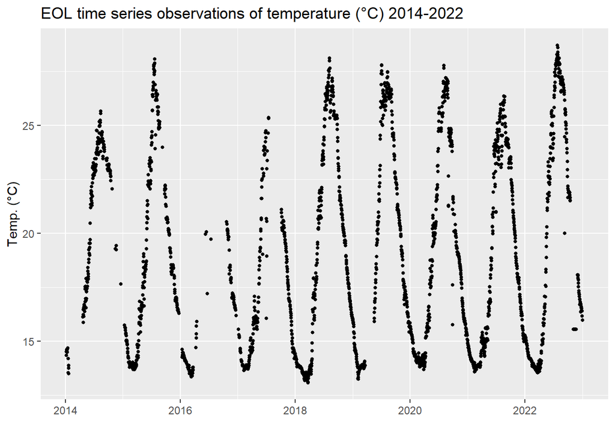

[figure not shown]

**EOL 1 : Plot of anomalies : Salinity (2014-2022) - EOL**

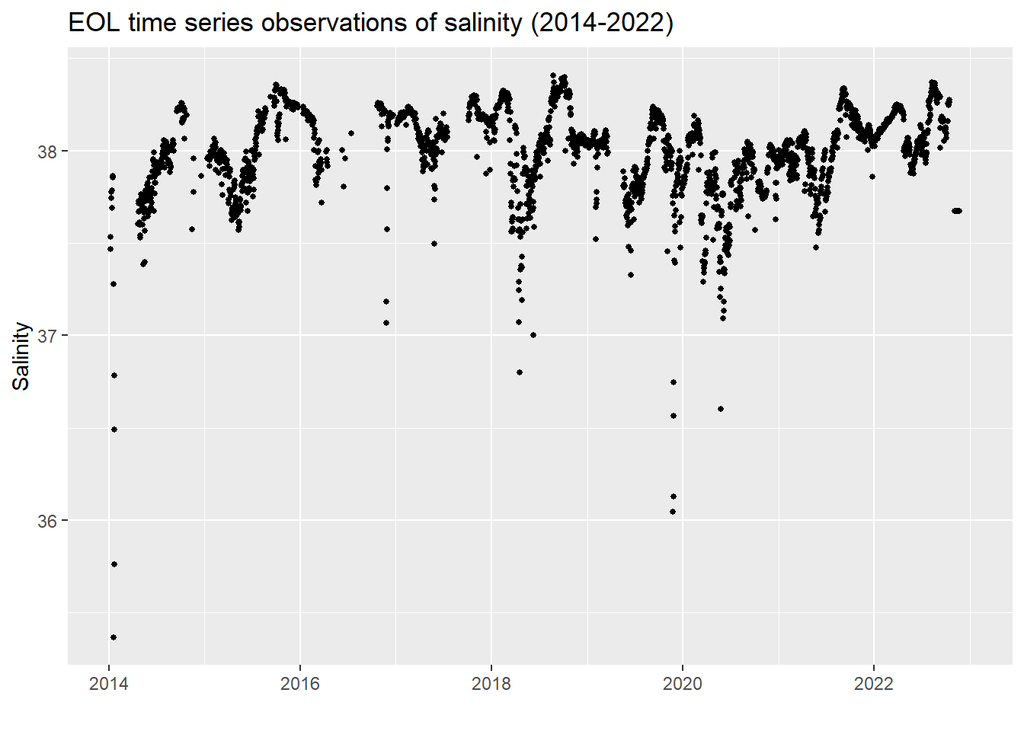

[figure not shown]

#### Part 3 : Trend analysis by residuals : hourly dataset jan.2018 - dec.2022

###### EOL 3 : Table and plot of monthly means (2018-2022) - EOL temperature & salinity

```r
monthly_means_EOL3 <- ungroup(EOL_daily_3) %>%
  mutate(Month = format(datetime, format="%m")) %>%
  group_by(Month) %>%
  summarise(
    Salinity_month = mean(salinity, na.rm = TRUE),
    Temperature_month = mean(temperature, na.rm = TRUE))

monthly_means_EOL3
```

```
## # A tibble: 12 x 3
##    Month Salinity_month Temperature_month
##    <chr>          <dbl>             <dbl>
##  1 01              38.0              14.6
##  2 02              38.1              13.9
##  3 03              38.0              13.9
##  4 04              37.9              15.1
##  5 05              37.8              18.2
##  6 06              37.8              22.4
##  7 07              37.9              26.1
##  8 08              38.1              26.7
##  9 09              38.2              24.5
## 10 10              38.1              21.2
## 11 11              37.7              18.7
## 12 12              38.0              16.4
```

###### EOL 3 : Table of time series anomalies regression analyses (2018-2022) - EOL temperature & salinity

```
##                       Slope    SE Slope      P Slope  Intercept  SE int.
## Salinity_ano    0.002180482 0.003343217 5.142691e-01  -4.405545 6.754789
## Temperature_ano 0.031907171 0.004104018 7.749749e-15 -64.468202 8.292140
##                       P int.          F    df           R2      P value
## Salinity_ano    5.142692e-01  0.4253788 38854 1.094802e-05 5.142691e-01
## Temperature_ano 7.749869e-15 60.4446808 39615 1.523478e-03 7.749749e-15
```

**EOL 3 : Plot of anomalies : Temperature (°C) (2018-2022) - EOL**

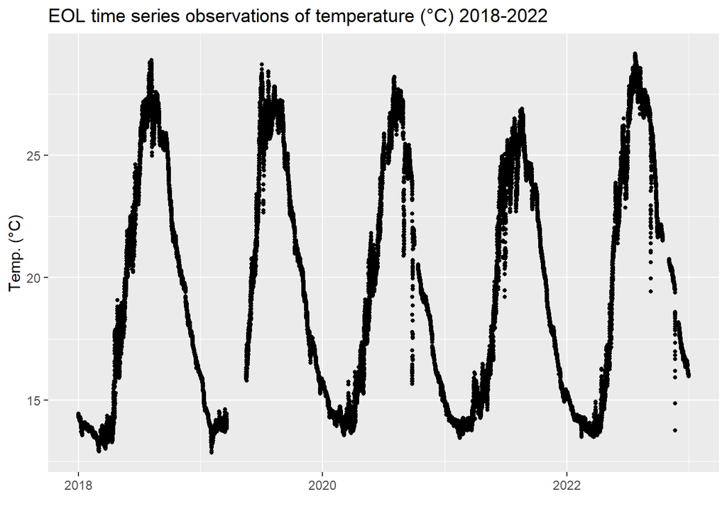

[figure not shown]

**EOL 3 : Plot of anomalies : Salinity (2018-2022) - EOL**

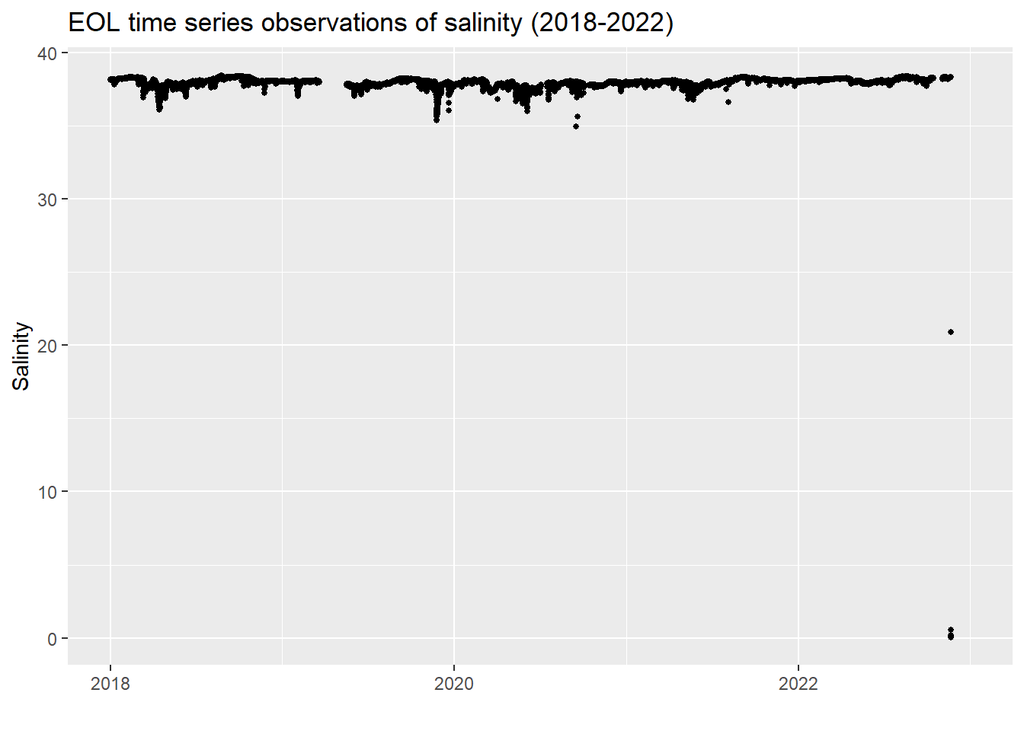

[figure not shown]

## Comparison between EOL and Point B on same period (2014-2022)

```
##                        Slope   SE Slope   P Slope Intercept  SE int.     P int.
## Salinity_ano    -0.006662333 0.00575050 0.2472266  13.44778 11.60728 0.24722696
## Temperature_ano  0.042910155 0.02167149 0.0482882 -86.61326 43.74349 0.04828839
##                        F  df          R2   P value
## Salinity_ano    1.342275 466 0.002872145 0.2472266
## Temperature_ano 3.920511 466 0.008342923 0.0482882
```

##### **Point B : Plot of anomalies : Temperature (°C) (2014-2022)**

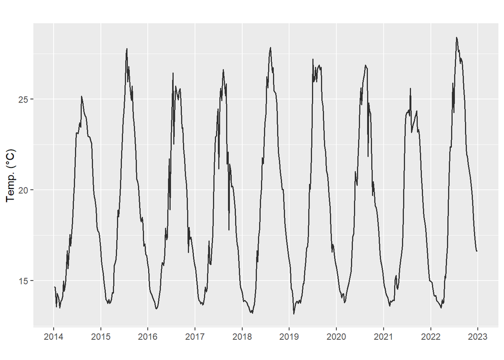

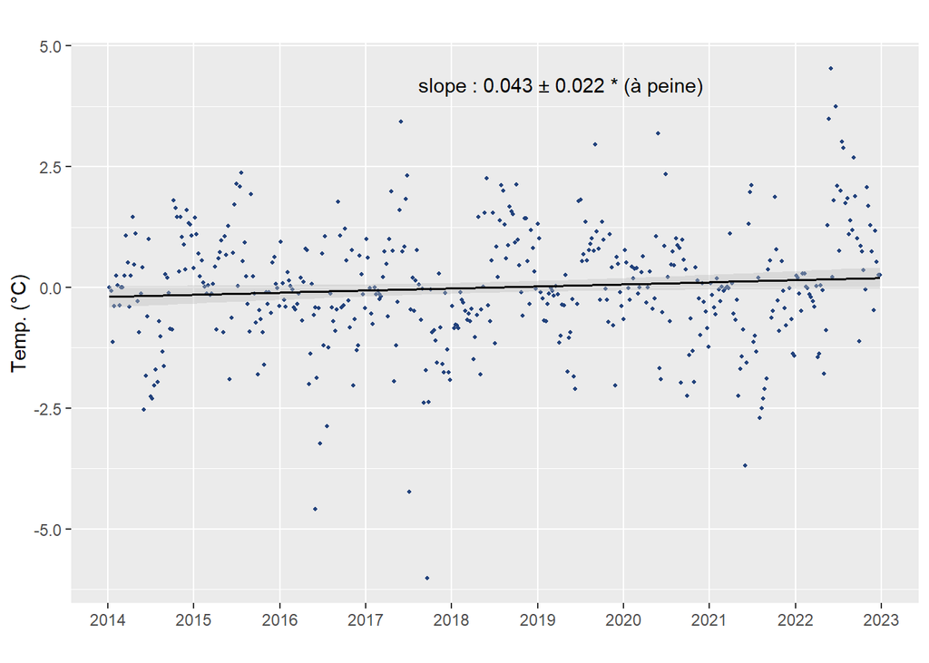

##### **Point B : Plot of anomalies : Salinity (2014-2022)**

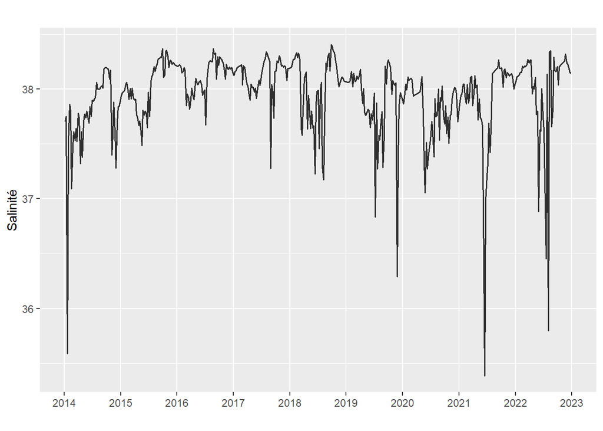

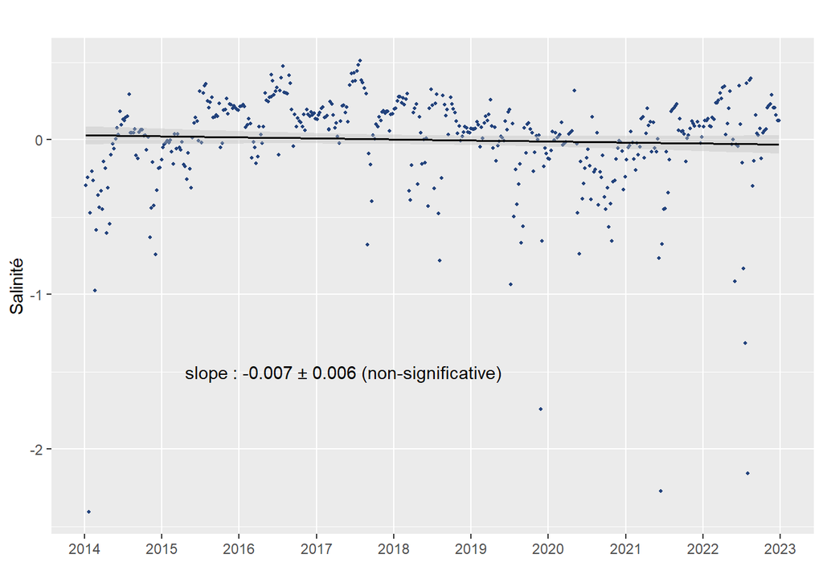

###### Moving average + Mann Kendall : Temperature Pt B (2014-2022)

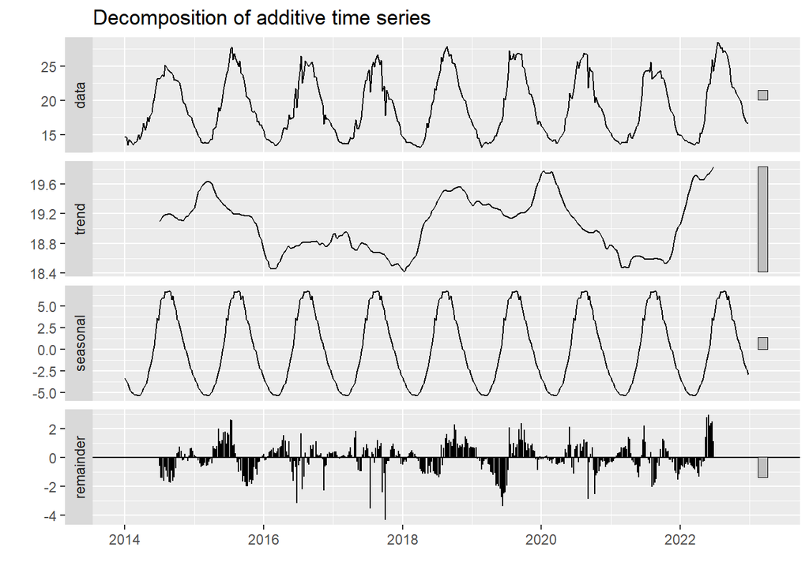

```
##
## Call:
## lm(formula = y ~ x, data = reg_val_ts_temp_som_less_season)
##
## Residuals:
##     Min      1Q  Median      3Q     Max
## -4.7539 -0.7045 -0.0455  0.6575  3.4482
##
## Coefficients:
##              Estimate Std. Error t value Pr(>|t|)
## (Intercept) -50.56917   40.89300  -1.237   0.2169
## x             0.03452    0.02026   1.704   0.0891 .
## ---
## Signif. codes:  0 '***' 0.001 '**' 0.01 '*' 0.05 '.' 0.1 ' ' 1
##
## Residual standard error: 1.139 on 466 degrees of freedom
## Multiple R-squared:  0.006191,   Adjusted R-squared:  0.004059
## F-statistic: 2.903 on 1 and 466 DF,  p-value: 0.08908
```

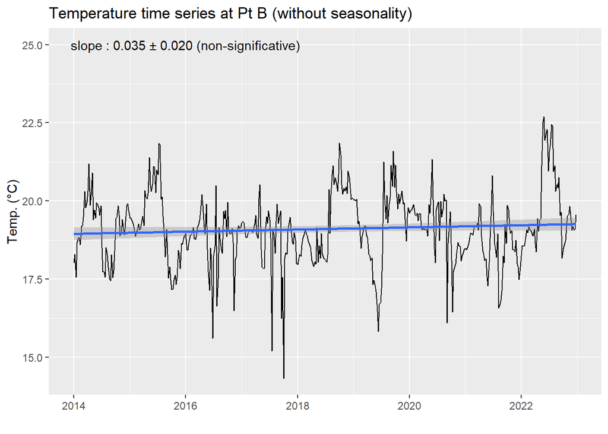

```
##         tau       slope   intercept
##  0.02637552  0.01302857 15.13428000
```

###### Moving average + Mann Kendall : Salinity Pt B (2014-2022)

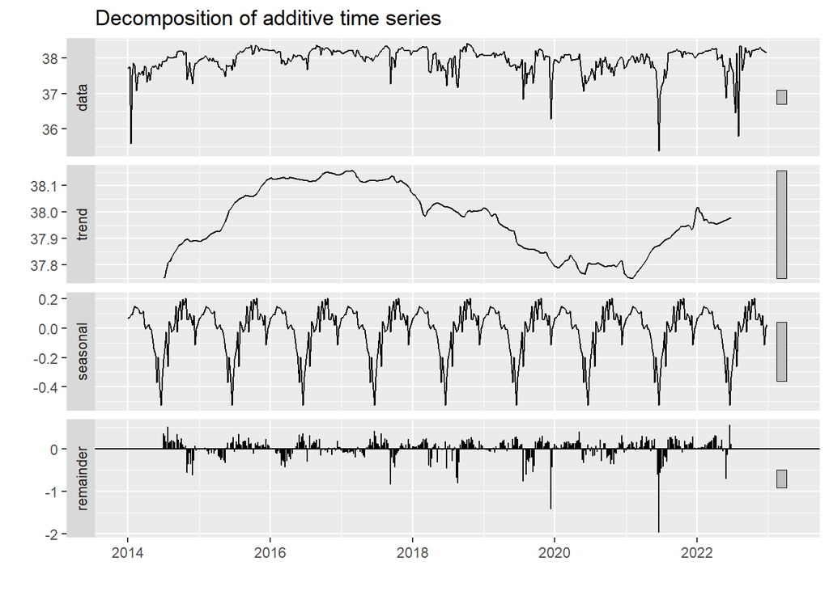

```
##
## Call:
## lm(formula = y ~ x, data = reg_val_ts_sal_som_less_season)
##
## Residuals:
##      Min       1Q   Median       3Q      Max
## -2.47683 -0.09634  0.06484  0.18904  0.59697
##
## Coefficients:
##              Estimate Std. Error t value Pr(>|t|)
## (Intercept) 48.200108  11.649750   4.137 4.17e-05 ***
## x           -0.005076   0.005772  -0.880     0.38
## ---
## Signif. codes:  0 '***' 0.001 '**' 0.01 '*' 0.05 '.' 0.1 ' ' 1
##
## Residual standard error: 0.3244 on 466 degrees of freedom
## Multiple R-squared:  0.001657,   Adjusted R-squared:  -0.000485
## F-statistic: 0.7736 on 1 and 466 DF,  p-value: 0.3796
```

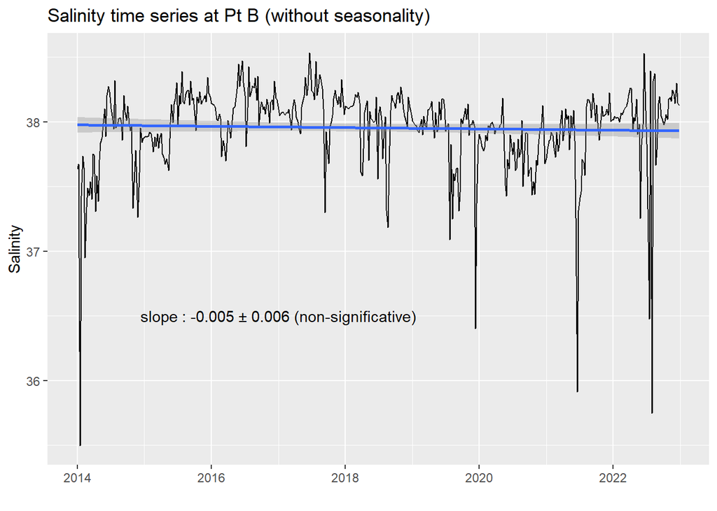

```
##          tau        slope    intercept
## -0.012983578 -0.001968333 55.826489524
```

## Comparison between EOL and Azur buoy - SST data 2014-2022

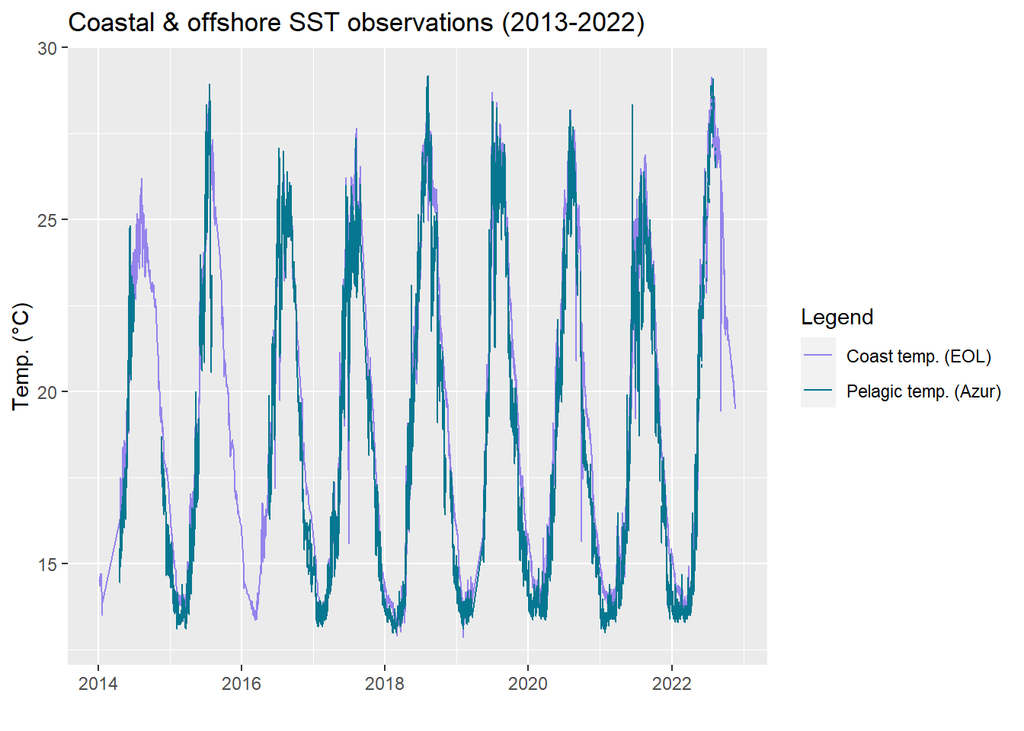

## Annual cycles EOL 3 : temperature and oxygen

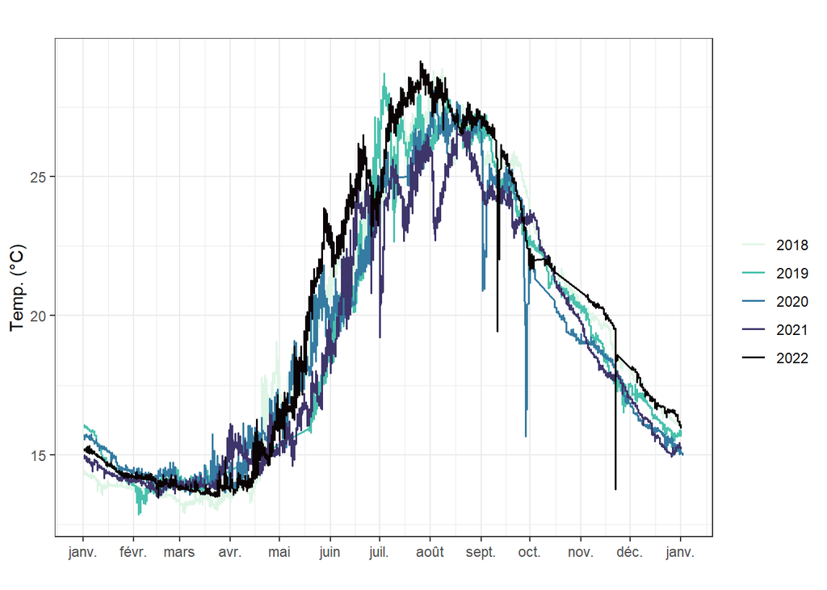

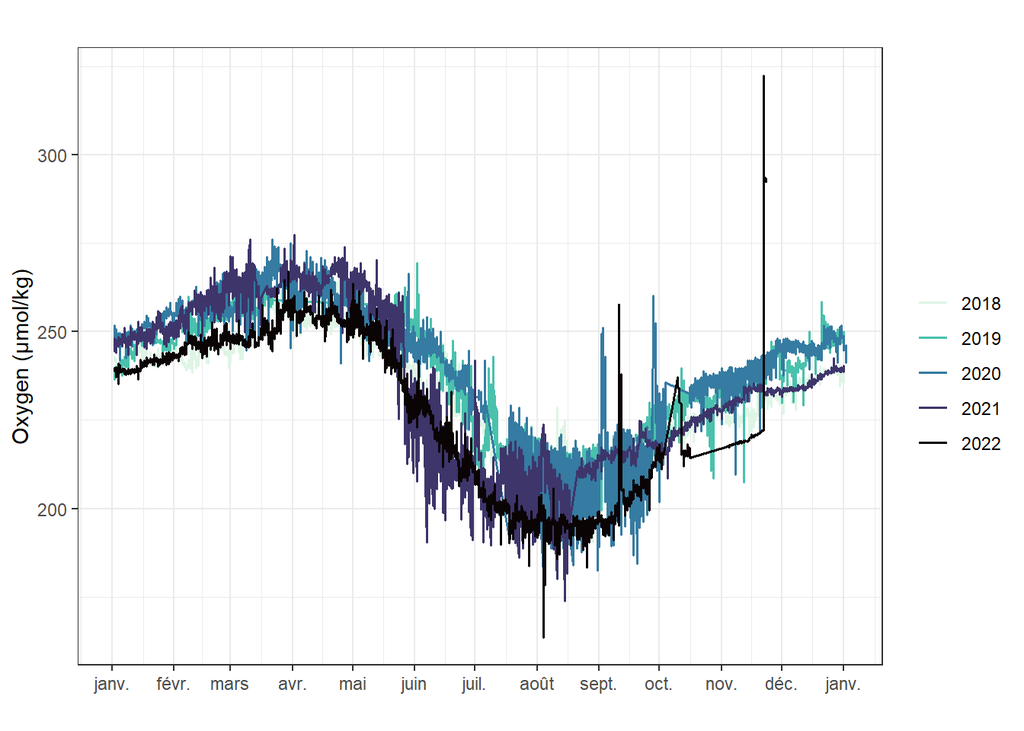

## Scatterplot costal (EOL) vs pelagic (Azur) SST :

```
##
## Call:
## lm(formula = temperature ~ temp_pelag, data = pelagic_coast)
##
## Residuals:
##     Min      1Q  Median      3Q     Max
## -6.7248 -0.4792 -0.0885  0.4674  6.4946
##
## Coefficients:
##              Estimate Std. Error t value Pr(>|t|)
## (Intercept) 0.7650631  0.0036550   209.3   <2e-16 ***
## temp_pelag  0.9994106  0.0001944  5140.5   <2e-16 ***
## ---
## Signif. codes:  0 '***' 0.001 '**' 0.01 '*' 0.05 '.' 0.1 ' ' 1
##
## Residual standard error: 0.8539 on 968158 degrees of freedom
##   (82971 observations effacées parce que manquantes)
## Multiple R-squared:  0.9647, Adjusted R-squared:  0.9647
## F-statistic: 2.643e+07 on 1 and 968158 DF,  p-value: < 2.2e-16
```

## Wind speed data (m/s)

→ Comparison between wind EOL modelisation and wind data of St-Jean-Cap-Ferrat station :

*model EOL : Jan.2009 - Dec.2022*  
*data Cap-Ferrat : Dec.2020 - Jan.2022*

Frequency : hourly  
Unity : m/s

##### **Histogram of wind speed distribution : model vs Cap-Ferrat**

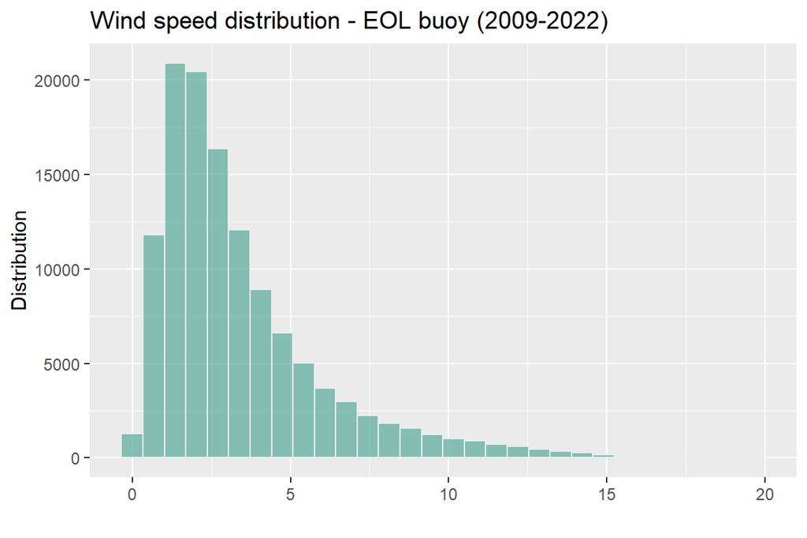

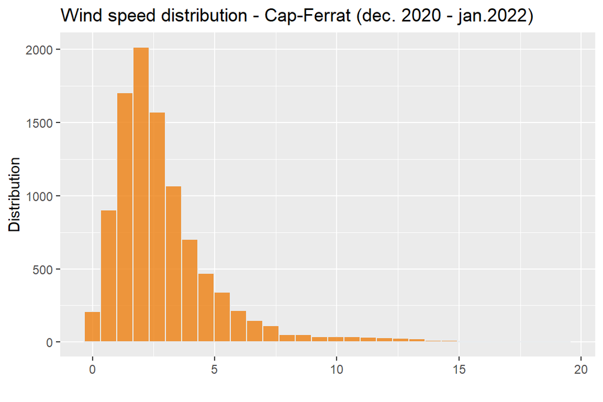

##### **Visualisation of EOL and Cap-Ferrat wind speeds (per hour) :**

##### **Visualisation of EOL and Cap-Ferrat wind speeds (means per day) :**

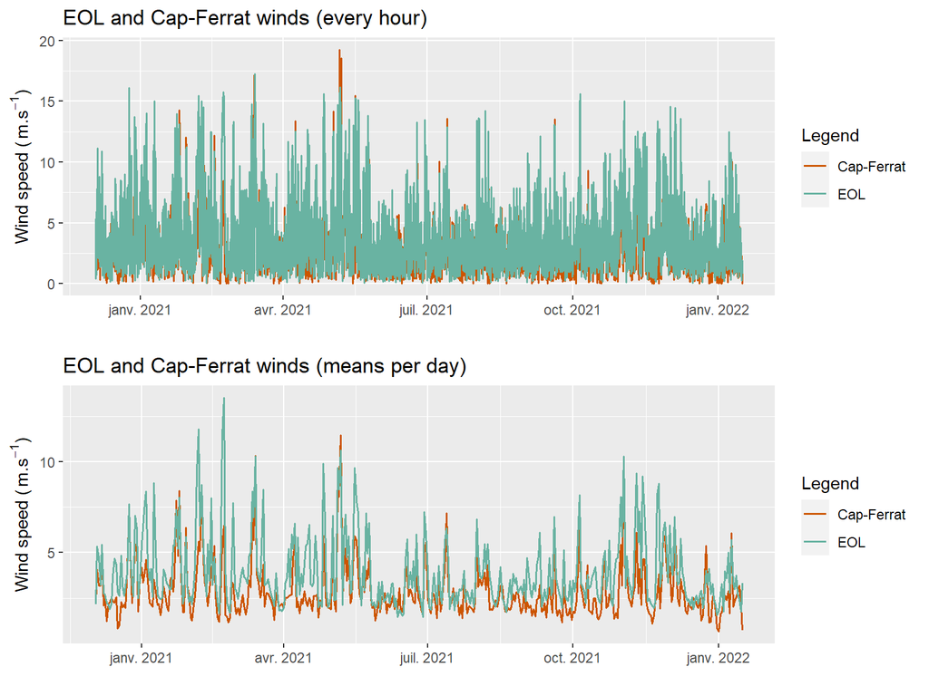

##### Scatterplot EOL vs Cap-Ferrat (wind speed m/s 10m) :

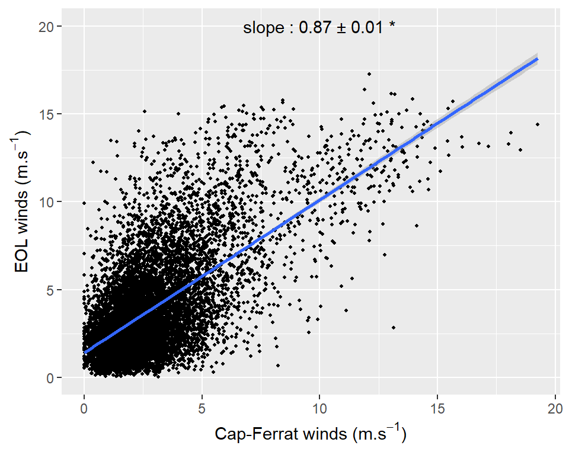

## Heatwaves :

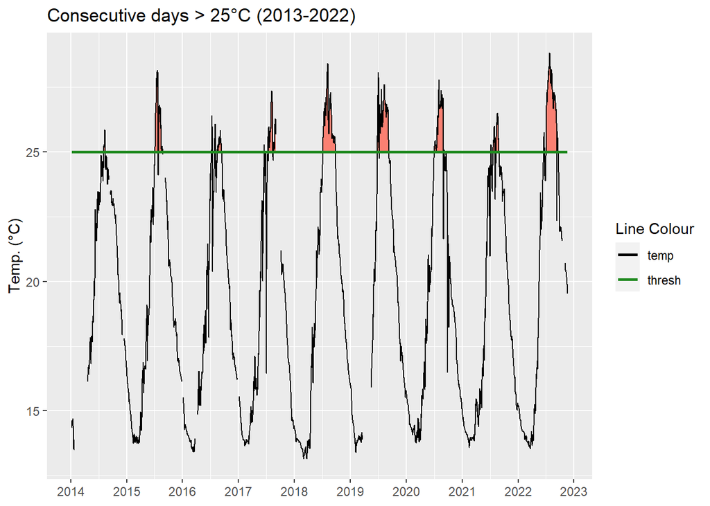